# Union Status Project

Factors with no significiant effect:

- Gender
- ContinuingEd

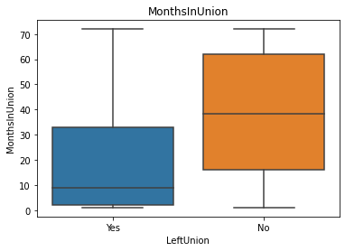

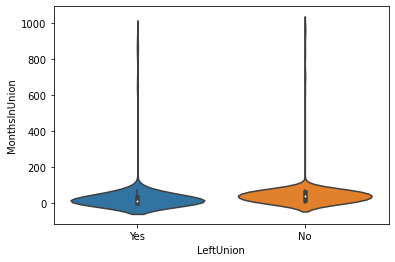

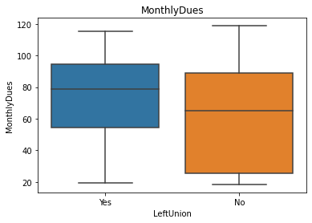

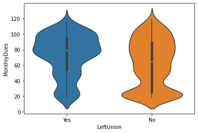

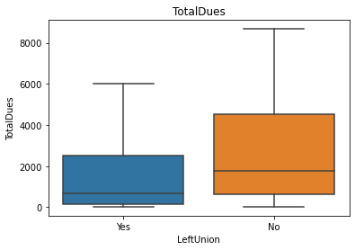

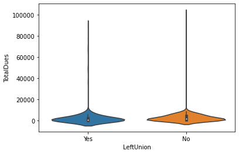

```python
# grouped boxplots and violinplots for the bivariate distributions of the target with each numerical variable
for n in numeric:
    plt.title(n)
    sns.boxplot(x=pd_df['LeftUnion'], y=pd_df[n],showfliers=False)
    plt.show()
    sns.violinplot(x=pd_df['LeftUnion'], y=pd_df[n],showfliers=False)
    plt.show()
```

An individual is more likely to leave the union if they:

- Have been in the union for less time
- Pay higher monthly dues
- Have paid less dues in total (likely because of less time in union)

To explore that last point, let's create a new feature 'AvgMonthlyDues' defined as TotalDues/MonthsInUnion.

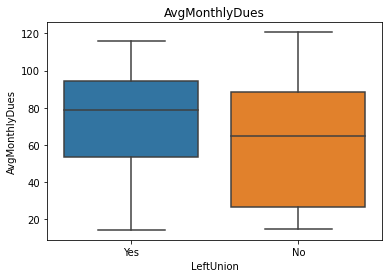

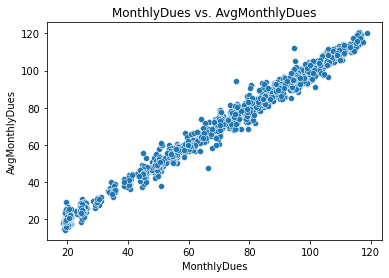

```python
pd_df['AvgMonthlyDues'] = pd_df['TotalDues']/pd_df['MonthsInUnion']
n = 'AvgMonthlyDues'
plt.title(n)
sns.boxplot(x=pd_df['LeftUnion'], y=pd_df[n],showfliers=False)
plt.show()
plt.title('MonthlyDues vs. AvgMonthlyDues')
sns.scatterplot(x=pd_df['MonthlyDues'],y=pd_df['AvgMonthlyDues'])
plt.show()
```

```python
pd_df[['MonthlyDues','AvgMonthlyDues']].head()
```

|  | MonthlyDues | AvgMonthlyDues |
| --- | --- | --- |
| 0 | 24.45 | 24.450000 |
| 1 | 74.45 | 74.687234 |
| 2 | 21.20 | 17.350000 |
| 3 | 74.60 | 71.910000 |
| 4 | 91.95 | 91.695833 |

This boxplot looks almost identical to the MonthlyDues feature, and it makes sense that TotalDues is very likely a transformation of MonthlyDues multiplied by MonthsInUnion. Therefore, we should discard the TotalDues feature.

## Further Pre-Processing

```python
# Redefine feature groups based on EDA findings
idx = ['ID']
categorical = ['Management','USAcitizen','Married','StateOfResidence','Connectivity','FeatureA',\
               'FeatureB','FeatureC','FeatureD','FeatureE','FeatureF','DuesFrequency','PaperlessBilling','PaymentMethod']
    # removed 'gender' and 'ContinuingEd' because they were found to have no significant impact on the target
categorical_idx = [s +'_idx' for s in categorical]
categorical_enc = [s+'_enc' for s in categorical]
numeric = ['MonthsInUnion','MonthlyDues']
# Removed TotalDues because it is essentially a transformation of the other two numeric features
predictors = categorical + numeric
target = ['LeftUnion']
```

```python
# import libraries
from pyspark.ml.feature import VectorAssembler, StringIndexer, OneHotEncoder, StandardScaler
from pyspark.ml import Pipeline
from pyspark.ml.classification import LogisticRegression
```

```python
# Create and use pipeline to encode and standardize the data, and create features column
indexer = StringIndexer(inputCols=categorical, outputCols=categorical_idx)
ohe = OneHotEncoder(inputCols=categorical_idx,outputCols=categorical_enc)
predictors_enc = categorical_enc + numeric
assembler = VectorAssembler(inputCols=predictors_enc, outputCol='features')
scaler = StandardScaler(inputCol='features', outputCol='scaledFeatures', withStd=True, withMean=True)
clean = Pipeline(stages=[indexer,ohe,assembler,scaler])
```

```python
# Encode, standardize, and assemble predictors
clean_df = clean.fit(df).transform(df)
```

```python
# Convert target variable LeftUnion to 1 for Yes (left union) and 0 for No (stayed in union)
import pyspark.sql.functions as F
if 'LeftUnion_enc' not in clean_df.columns:
    clean_df = clean_df.withColumn('LeftUnion_enc',F.when(clean_df.LeftUnion=='Yes',1).otherwise(0))
```

```python
clean_df.select("ID","LeftUnion_enc","scaledFeatures").show(3,truncate=False)
```

```
+-----+-------------+---------------------------------------------------------------------------------------------------------------------------------------------------------------------------------------------------------------------------------------------------------------------------------------…
|ID   |LeftUnion_enc|scaledFeatures                                                                                                                                                                                                                                                                         …
+-----+-------------+---------------------------------------------------------------------------------------------------------------------------------------------------------------------------------------------------------------------------------------------------------------------------------------…
|16242|1            |[0.43886477956900777,0.9541368432705561,0.6569141792541348,0.8586071293253853,-0.898957318610688,1.3861179136408324,0.9992475859827484,-0.6374077422053286,1.139332967493609,-0.7404642489222963,1.1118417116823547,-0.7210773585835604,0.9982453306249163,-0.6366295961918195,1.194491…
|18805|0            |[0.43886477956900777,0.9541368432705561,0.6569141792541348,0.8586071293253853,-0.898957318610688,1.3861179136408324,0.9992475859827484,-0.6374077422053286,1.139332967493609,-0.7404642489222963,-0.898957318610688,1.3861179136408324,-1.0012551155413734,1.5699839433043479,-0.836755…
|14120|0            |[0.43886477956900777,0.9541368432705561,0.6569141792541348,0.8586071293253853,-0.898957318610688,-0.7210773585835604,-1.0002508466112452,-0.6374077422053286,-0.8772661481500524,-0.7404642489222963,-0.898957318610688,-0.7210773585835604,-1.0012551155413734,-0.6366295961918195,-0.…
+-----+-------------+---------------------------------------------------------------------------------------------------------------------------------------------------------------------------------------------------------------------------------------------------------------------------------------…
only showing top 3 rows
```

## Build and Evaluate Models

```python
# Split the data into train and test data sets
df_train, df_test = clean_df.randomSplit([0.7,0.3],seed=2003)
```

```python
df_train.head()
```

```
Row(ID='12958', gender='Female', Management=0, USAcitizen='Yes', Married='Yes', MonthsInUnion=872, ContinuingEd='No', StateOfResidence='MO', Connectivity='DSL', FeatureA='Yes', FeatureB='No', FeatureC='No', FeatureD='No', FeatureE='No', FeatureF='No', DuesFrequency='Month-to-month', PaperlessBilling…
```

### Logistic Regression Model

**Build and Train Model**

```python
# Build model
from pyspark.ml.classification import LogisticRegression
log_reg = LogisticRegression(featuresCol='scaledFeatures', labelCol='LeftUnion_enc')
log_model = log_reg.fit(df_train)
log_results = log_model.transform(df_test)
log_results.select("ID","LeftUnion_enc","prediction","probability").show(5,truncate=False)
```

```
+-----+-------------+----------+-----------------------------------------+
|ID   |LeftUnion_enc|prediction|probability                              |
+-----+-------------+----------+-----------------------------------------+
|12959|0            |0.0       |[0.807215888747269,0.19278411125273098]  |
|12969|0            |1.0       |[0.4916292627224937,0.5083707372775064]  |
|12970|0            |0.0       |[0.9858718031387778,0.014128196861222242]|
|12985|0            |0.0       |[0.5471701453582885,0.45282985464171155] |
|12989|1            |0.0       |[0.5300500457497432,0.46994995425025676] |
+-----+-------------+----------+-----------------------------------------+
only showing top 5 rows
```

**Evaluate Model**

```python
from pyspark.ml.evaluation import MulticlassClassificationEvaluator
evaluator = MulticlassClassificationEvaluator(predictionCol="prediction",labelCol="LeftUnion_enc")
log_accuracy = evaluator.evaluate(log_results,{evaluator.metricName: 'accuracy'})
print('logistic regression model accuracy:',log_accuracy)
```

```
logistic regression model accuracy: 0.7579298831385642
```

```python
log_accuracy_df = pd.DataFrame(data={'model':['logistic_regression'],'accuracy':[log_accuracy]})
accuracy_df = pd.concat([accuracy_df,log_accuracy_df])
```

```
[[0.63439065 0.0884808 ]
 [0.15358932 0.12353923]]
```

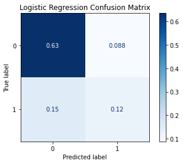

```python
from sklearn.metrics import confusion_matrix, ConfusionMatrixDisplay
import numpy as np

log_results_pd = log_results.toPandas()

disp = ConfusionMatrixDisplay.from_predictions(y_true=log_results_pd['LeftUnion_enc'].to_numpy(),
                                               y_pred=log_results_pd['prediction'].to_numpy(),
                                 cmap=plt.cm.Blues,
                                 normalize='all')
disp.ax_.set_title("Logistic Regression Confusion Matrix")

print(disp.confusion_matrix)

plt.show()
```

### Decision Tree Model

**Build and Train Model**

```python
from pyspark.ml.classification import DecisionTreeClassifier
dt = DecisionTreeClassifier(labelCol="LeftUnion_enc", featuresCol="scaledFeatures")
dt_model = dt.fit(df_train)
dt_results = dt_model.transform(df_test)
dt_results.select("ID","LeftUnion_enc","prediction","probability").show(5,truncate=False)
```

```
+-----+-------------+----------+-----------------------------------------+
|ID   |LeftUnion_enc|prediction|probability                              |
+-----+-------------+----------+-----------------------------------------+
|12959|0            |0.0       |[0.7142857142857143,0.2857142857142857]  |
|12969|0            |0.0       |[0.8333333333333334,0.16666666666666666] |
|12970|0            |0.0       |[0.9644549763033176,0.035545023696682464]|
|12985|0            |1.0       |[0.49375,0.50625]                        |
|12989|1            |1.0       |[0.49375,0.50625]                        |
+-----+-------------+----------+-----------------------------------------+
only showing top 5 rows
```

**Evaluate Model**

```python
dt_accuracy = evaluator.evaluate(dt_results,{evaluator.metricName: 'accuracy'})
print('decision tree model accuracy:',dt_accuracy)
```

```
decision tree model accuracy: 0.7646076794657763
```

```python
dt_accuracy_df = pd.DataFrame(data={'model':['decision_tree'],'accuracy':[dt_accuracy]})
accuracy_df = pd.concat([accuracy_df,dt_accuracy_df])
```

```
[[0.61435726 0.10851419]
 [0.12687813 0.15025042]]
```

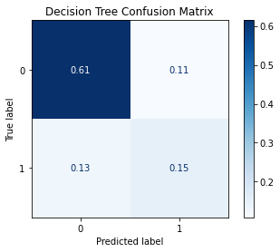

```python
dt_results_pd = dt_results.toPandas()

disp = ConfusionMatrixDisplay.from_predictions(y_true=dt_results_pd['LeftUnion_enc'].to_numpy(),
                                               y_pred=dt_results_pd['prediction'].to_numpy(),
                                 cmap=plt.cm.Blues,
                                 normalize='all')
disp.ax_.set_title("Decision Tree Confusion Matrix")

print(disp.confusion_matrix)

plt.show()
```

### Random Forest Model

**Build and Train Model**

```python
from pyspark.ml.classification import RandomForestClassifier
rf = RandomForestClassifier(labelCol="LeftUnion_enc", featuresCol="scaledFeatures", numTrees=1000)
rf_model = rf.fit(df_train)
rf_results = rf_model.transform(df_test)
rf_results.select("ID","LeftUnion_enc","prediction","probability").show(5,truncate=False)
```

```
+-----+-------------+----------+----------------------------------------+
|ID   |LeftUnion_enc|prediction|probability                             |
+-----+-------------+----------+----------------------------------------+
|12959|0            |0.0       |[0.7497996374365697,0.2502003625634303] |
|12969|0            |0.0       |[0.6811238174461013,0.31887618255389866]|
|12970|0            |0.0       |[0.8795362975365051,0.12046370246349498]|
|12985|0            |0.0       |[0.6253781769246087,0.37462182307539127]|
|12989|1            |0.0       |[0.5790999765026025,0.4209000234973976] |
+-----+-------------+----------+----------------------------------------+
only showing top 5 rows
```

**Evaluate Model**

```python
rf_accuracy = evaluator.evaluate(rf_results,{evaluator.metricName: 'accuracy'})
print('random forest model accuracy:', rf_accuracy)
```

```
random forest model accuracy: 0.7796327212020033
```

```python
rf_accuracy_df = pd.DataFrame(data={'model':['random_forest'],'accuracy':[rf_accuracy]})
accuracy_df = pd.concat([accuracy_df,rf_accuracy_df])
```

```
[[0.67612688 0.04674457]
 [0.1736227  0.10350584]]
```

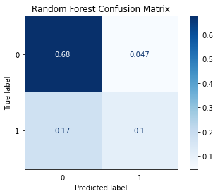

```python
rf_results_pd = rf_results.toPandas()

disp = ConfusionMatrixDisplay.from_predictions(y_true=rf_results_pd['LeftUnion_enc'].to_numpy(),
                                               y_pred=rf_results_pd['prediction'].to_numpy(),
                                 cmap=plt.cm.Blues,
                                 normalize='all')
disp.ax_.set_title("Random Forest Confusion Matrix")

print(disp.confusion_matrix)

plt.show()
```

### Support Vector Classifier (SVC)

**Build and Train Model**

```python
from pyspark.ml.functions import vector_to_array
df_train2 = df_train.withColumn("ftr", vector_to_array("scaledFeatures")).select(["LeftUnion_enc"] + [col("ftr")[i] for i in range(len(predictors))])
df_train2_pd = df_train2.toPandas()
X_train = df_train2_pd.loc[:,df_train2_pd.columns!='LeftUnion_enc']
y_train = df_train2_pd['LeftUnion_enc']

df_test2 = df_test.withColumn("ftr", vector_to_array("scaledFeatures")).select(["LeftUnion_enc"] + [col("ftr")[i] for i in range(len(predictors))])
df_test2_pd = df_test2.toPandas()
X_test = df_test2_pd.loc[:,df_train2_pd.columns!='LeftUnion_enc']
y_test = df_test2_pd['LeftUnion_enc']
```

```python
from sklearn.svm import SVC
svc_model = SVC()
svc_model.fit(X_train,y_train)
svc_predictions = svc_model.predict(X_test)
svc_results = pd.DataFrame(data={'actual':y_test,'predicted':svc_predictions})
svc_results.head()
```

|  | actual | predicted |
| --- | --- | --- |
| 0 | 0 | 0 |
| 1 | 0 | 1 |
| 2 | 0 | 0 |
| 3 | 0 | 1 |
| 4 | 1 | 0 |

**Evaluate Model**

```python
svc_accuracy = svc_results[svc_results.actual==svc_results.predicted].count()[0]/svc_results.count()[0]
print('svc accuracy:', svc_accuracy)
```

```
svc accuracy: 0.7579298831385642
```

```python
svc_accuracy_df = pd.DataFrame(data={'model':['support_vector_classifier'],'accuracy':[svc_accuracy]})
accuracy_df = pd.concat([accuracy_df,svc_accuracy_df])
```

```
[[0.64774624 0.07512521]
 [0.16694491 0.11018364]]
```

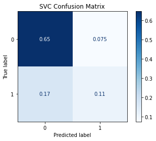

```python
disp = ConfusionMatrixDisplay.from_predictions(y_true=svc_results['actual'].to_numpy(),
                                               y_pred=svc_results['predicted'].to_numpy(),
                                 cmap=plt.cm.Blues,
                                 normalize='all')
disp.ax_.set_title("SVC Confusion Matrix")

print(disp.confusion_matrix)

plt.show()
```

## Tune the Models

**Use Principle Component Analysis (PCA) on the best performing models.**

```python
accuracy_df.sort_values(by='accuracy',ascending=False)
```

|  | model | accuracy |
| --- | --- | --- |
| 0 | random_forest | 0.779633 |
| 0 | decision_tree | 0.764608 |
| 0 | logistic_regression | 0.757930 |
| 0 | support_vector_classifier | 0.757930 |
| 0 | blind_guess | 0.733367 |

Perform PCA and transform data

```python
n = 3 # set the number of components; this will be tweaked

import pyspark.sql.functions as F
import pyspark.sql.types as T
to_array = F.udf(lambda v: v.toArray().tolist(), T.ArrayType(T.FloatType()))
clean_df = clean_df.withColumn('scaledFeatures_array', to_array('scaledFeatures'))
clean_df_pandas = clean_df.toPandas()
import numpy as np
x = clean_df_pandas.scaledFeatures_array
X = np.array([np.array(xi) for xi in x])
Y = np.array(clean_df_pandas.LeftUnion_enc.values)
from sklearn import decomposition
pca = decomposition.PCA(n_components=n)
pca.fit(X)
X = pca.transform(X)
X_data = list([list(xi) for xi in X])
pca_data = pd.DataFrame(data={'features':X_data,'label':Y})
PC=list(['PC'+str(i) for i in range(1,n+1)])
pca_data[PC] = pd.DataFrame(pca_data["features"].to_list())
pca_data.head()
```

|  | features | label | PC1 | PC2 | PC3 |
| --- | --- | --- | --- | --- | --- |
| 0 | [-2.498395172663547, -3.128202658022929, 1.011... | 1 | -2.498395 | -3.128203 | 1.011549 |
| 1 | [2.0994395244456956, 0.37549753170937505, 0.17... | 0 | 2.099440 | 0.375498 | 0.177472 |
| 2 | [1.8964136379187397, -3.0692584093682713, -1.9... | 0 | 1.896414 | -3.069258 | -1.967303 |
| 3 | [-2.678919843953882, 0.15744658922807442, -0.2... | 0 | -2.678920 | 0.157447 | -0.240194 |
| 4 | [-1.790482274376759, 1.9166002431477405, -0.48... | 0 | -1.790482 | 1.916600 | -0.484187 |

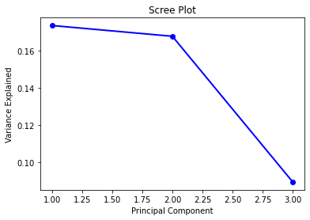

```python
# scree plot
PC_values = np.arange(pca.n_components_) + 1
plt.plot(PC_values, pca.explained_variance_ratio_, 'o-', linewidth=2, color='blue')
plt.title('Scree Plot')
plt.xlabel('Principal Component')
plt.ylabel('Variance Explained')
plt.show()
```

```python
# create a pyspark version of the pca data
spark_pca_data = spark.createDataFrame(pca_data.loc[:,pca_data.columns!='features'])
assembler = VectorAssembler(inputCols=PC, outputCol='features')
spark_pca_data = assembler.transform(spark_pca_data)
# Split the data into train and test data sets
pca_train, pca_test = spark_pca_data.randomSplit([0.7,0.3],seed=2003)
```

Try best-performing model (random forest) again, this time with PCA-transformed data

```python
rf = RandomForestClassifier(labelCol="label", featuresCol="features", numTrees=1000)
rf_model = rf.fit(pca_train)
rf_results = rf_model.transform(pca_test)
rf_results.select('label','prediction').show(5)
```

```
+-----+----------+
|label|prediction|
+-----+----------+
|    0|       1.0|
|    0|       0.0|
|    0|       0.0|
|    0|       0.0|
|    0|       0.0|
+-----+----------+
only showing top 5 rows
```

Evaluate Model

```python
evaluator = MulticlassClassificationEvaluator(predictionCol="prediction",labelCol="label")
pca_rf_accuracy = evaluator.evaluate(rf_results,{evaluator.metricName: 'accuracy'})
print('PCA random forest model accuracy:', pca_rf_accuracy)
```

```
PCA random forest model accuracy: 0.7842809364548495
```

```python
pca_rf_accuracy_df = pd.DataFrame(data={'model':['PCA_random_forest'],'accuracy':[pca_rf_accuracy]})
accuracy_df = pd.concat([accuracy_df,pca_rf_accuracy_df])
```

```
[[0.7006689  0.0367893 ]
 [0.17892977 0.08361204]]
```

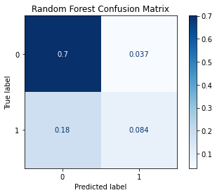

```python
rf_results_pd = rf_results.toPandas()

disp = ConfusionMatrixDisplay.from_predictions(y_true=rf_results_pd['label'].to_numpy(),
                                               y_pred=rf_results_pd['prediction'].to_numpy(),
                                 cmap=plt.cm.Blues,
                                 normalize='all')
disp.ax_.set_title("Random Forest Confusion Matrix")

print(disp.confusion_matrix)

plt.show()
```

Try different numbers of components

```
1 components -> accuracy = 0.7508361204013378
```

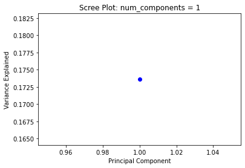

```
2 components -> accuracy = 0.7876254180602007
```

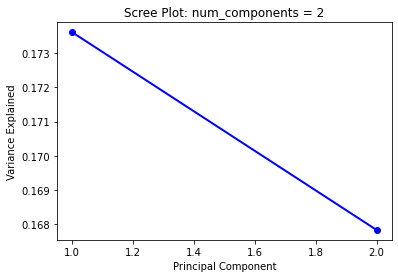

```
3 components -> accuracy = 0.7859531772575251
```

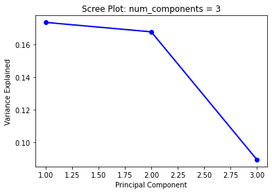

```
4 components -> accuracy = 0.7809364548494984
```

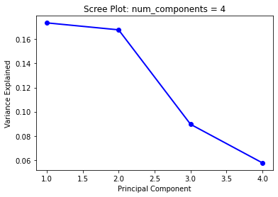

```
5 components -> accuracy = 0.7809364548494984
```

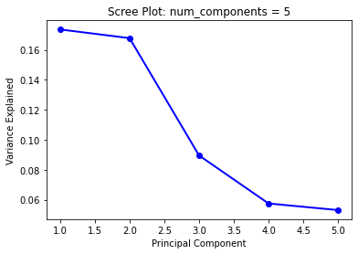

```
{1: 0.7508361204013378,
 2: 0.7876254180602007,
 3: 0.7859531772575251,
 4: 0.7809364548494984,
 5: 0.7809364548494984}
```

```python
pca_accuracy_dict = {}
for n in range(1,6):
    x = clean_df_pandas.scaledFeatures_array
    X = np.array([np.array(xi) for xi in x])
    Y = np.array(clean_df_pandas.LeftUnion_enc.values)

    pca = decomposition.PCA(n_components=n)
    pca.fit(X)
    X = pca.transform(X)
    X_data = list([list(xi) for xi in X])
    pca_data = pd.DataFrame(data={'features':X_data,'label':Y})
    PC=list(['PC'+str(i) for i in range(1,n+1)])
    pca_data[PC] = pd.DataFrame(pca_data["features"].to_list())

    # create a pyspark version of the pca data
    spark_pca_data = spark.createDataFrame(pca_data.loc[:,pca_data.columns!='features'])
    assembler = VectorAssembler(inputCols=PC, outputCol='features')
    spark_pca_data = assembler.transform(spark_pca_data)
    # Split the data into train and test data sets
    pca_train, pca_test = spark_pca_data.randomSplit([0.7,0.3],seed=2003)

    # train model
    rf_model = rf.fit(pca_train)
    rf_results = rf_model.transform(pca_test)

    # evaluate model
    pca_rf_accuracy = evaluator.evaluate(rf_results,{evaluator.metricName: 'accuracy'})
    pca_accuracy_dict[n]=pca_rf_accuracy
    print(n,'components -> accuracy =',pca_rf_accuracy)

    # scree plot
    PC_values = np.arange(pca.n_components_) + 1
    plt.plot(PC_values, pca.explained_variance_ratio_, 'o-', linewidth=2, color='blue')
    plt.title('Scree Plot: num_components = ' + str(n))
    plt.xlabel('Principal Component')
    plt.ylabel('Variance Explained')
    plt.show()

pca_accuracy_dict
```

```python
accuracy_df.sort_values(by='accuracy',ascending=False)
```

|  | model | accuracy |
| --- | --- | --- |
| 0 | PCA_random_forest | 0.784281 |
| 0 | random_forest | 0.779633 |
| 0 | decision_tree | 0.764608 |
| 0 | logistic_regression | 0.757930 |
| 0 | support_vector_classifier | 0.757930 |
| 0 | blind_guess | 0.733367 |

## Conclusions and Reflections

With more time, I would explore other models and the influence of PCA on the other models used, not just the best performing one. However, it was reasonable of me to assume that the best performing model without PCA would still be the best performing model when using PCA.